# The Mechanics of Data Visualization

Mike Mahoney

Let’s move from theoretical considerations of graphing to the actual building blocks you have at your disposal. As we do so, we’re also going to move on to mantra #2:

## Everything should be made as simple as possible – but no simpler.

Graphs are inherently a 2D image of our data:

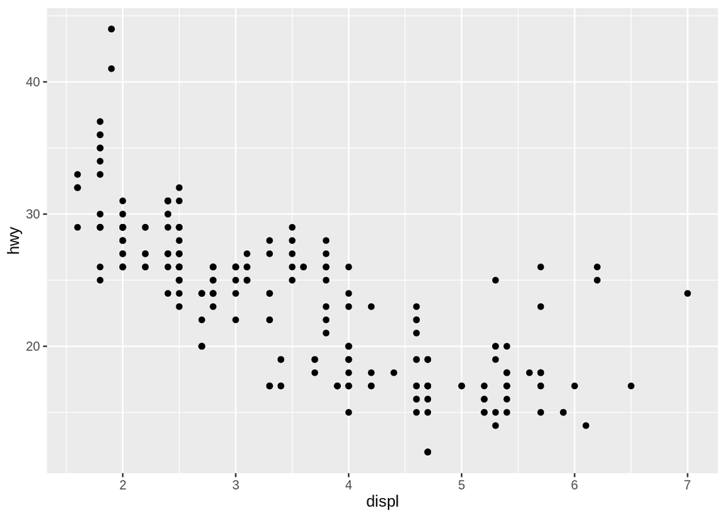

```r
knitr::opts_chunk$set(warning = F, message = F)
library(ggplot2)
ggplot(mpg, aes(displ, hwy)) +
  geom_point()
```

They have an x and a y scale, and - as in our scatterplot here - the position a point falls along each scale tells you how large its values are. But this setup only allows us to look at two variables in our data - and we’re frequently interested in seeing relationships between more than two variables.

So the question becomes: how can we visualize those extra variables? We can try adding another position scale:

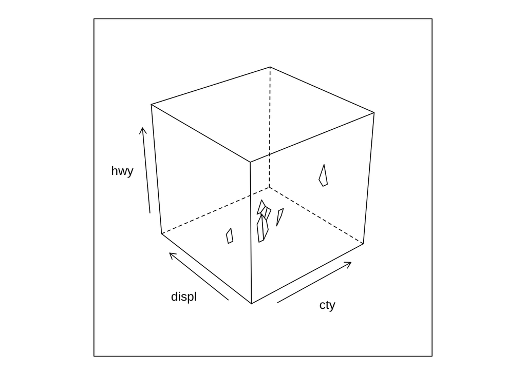

```r
library(lattice)
wireframe(hwy ~ cty + displ, data = mpg)
```

But 3D images are hard to wrap your head around, complicated to produce, and not as effective in delivering your message. They do have their uses - particularly when you’re able to build real 3D models, and not just make 3D shapes on 2D planes - but frequently aren’t worth the trouble.

So what tools do we have in our toolbox? The ones that are generally agreed upon (no, really - this is an area of active debate) fall into four categories:

- Position (like we already have with X and Y)
- Color
- Shape
- Size

These are the tools we can use to encode more information into our graphics. We’re going to call these *aesthetics*, but any number of other words could work - some people refer to them as scales, some as values. I call them aesthetics because that’s what my software of choice calls them - but the word itself comes from the fact that these are the things that change how your graph looks.

For what it’s worth, we’re using an EPA dataset for this unit, representing fuel economy data from 1999 and 2008 for 38 popular models of car. “Hwy” is highway mileage, “displ” is engine displacement (so volume), and “cty” is city mileage. But frankly, our dataset doesn’t matter right now - most of our discussion here is applicable to any dataset you’ll pick up.

We’re going to go through each of these aesthetics, to talk about how you can encode more information in each of your graphics. Along the way, remember our mantras:

1. A good graphic tells a story
2. Everything should be made as simple as possible - but no simpler
3. Use the right tool for the job
4. Ink is cheap. Electrons are even cheaper

We’ll talk about how these are applicable throughout this section.

### Position

Let’s start off discussing these aesthetics by finishing up talking about position. The distance of values along the x, y, or – in the case of our 3D graphic – z axes represents how large a particular variable is. People inherently understand that values further out on each axis are more extreme - for instance, imagine you came across the following graphic (made with simulated data):

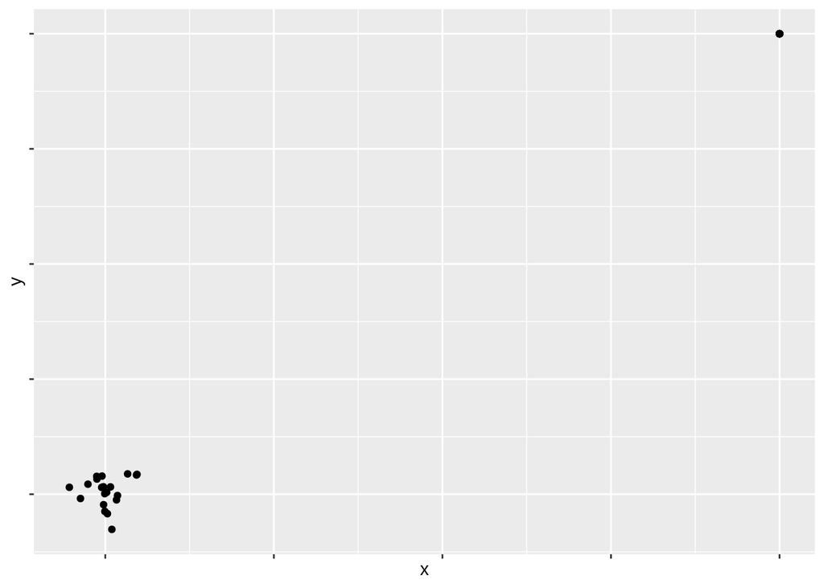

```r
library(dplyr)
tibble(x = rnorm(20, 0, 0.5),
       y = rnorm(20, 0, 0.5)) %>%
  ggplot(aes(x, y)) +
  geom_point() +
  geom_point(aes(x = 20, y = 20)) +
  theme(axis.text = element_blank())
```

Which values do you think are higher?

Most people innately assume that the bottom-left hand corner represents a 0 on both axes, and that the further you get from that corner the higher the values are. This – relatively obvious – revelation hints at a much more important concept in data visualizations: perceptual topology should match data topology. Values that feel larger in a graph should represent values that *are* larger in your data. As such, when working with position, higher values should be the ones further away from that lower left-hand corner – you should let your viewer’s subconscious assumptions do the heavy lifting for you.

Applying this advice to categorical data can get a little tricky. Imagine that we’re looking at the average highway mileages for manufacturers of the cars in our dataset:

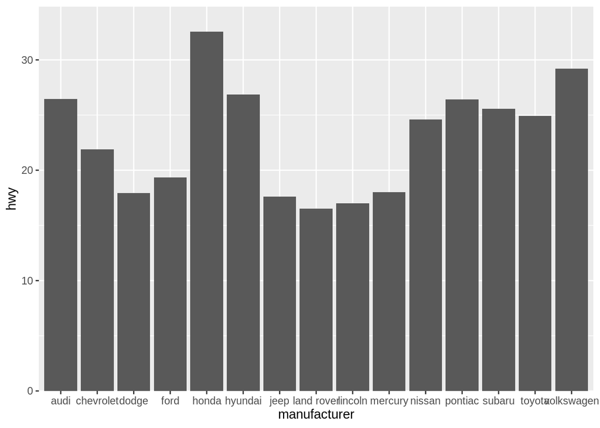

```r
mpg %>%
  group_by(manufacturer) %>%
  summarise(hwy = mean(hwy)) %>%
  ggplot(aes(manufacturer, hwy)) +
  geom_col() +
  scale_y_continuous(expand = expand_scale(mult = c(0, 0.07)))
```

In this case, the position along the x axis just represents a different car maker, in alphabetical order. But remember, position in a graph is an aesthetic that we can use to encode more information in our graphics. And we aren’t doing that here – for instance, we could show the same information without using x position at all:

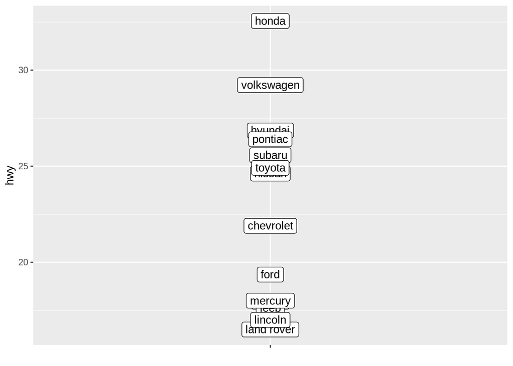

```r
mpg %>%
  group_by(manufacturer) %>%
  summarise(hwy = mean(hwy)) %>%
  ggplot(aes(1, hwy, label = manufacturer)) +
  geom_label() +
  scale_x_discrete(limits = c(1, 1)) +
  theme(axis.text.x = element_blank()) +
  labs (x = "")
```

Try to compare Pontiac and Hyundai on the first graph, versus on this second one. If anything, removing our extraneous x aesthetic has made it easier to compare manufacturers. This is a big driver behind our second mantra – that everything should be made as simple as possible, but no simpler. Having extra aesthetics confuses a graph, making it harder to understand the story it’s trying to tell.

However, when making a graphic, we should always be aiming to make important comparisons easy. As such, we should take advantage of our x aesthetic, arranging our manufacturers not by the alphabet, but rather by their average highway mileage:

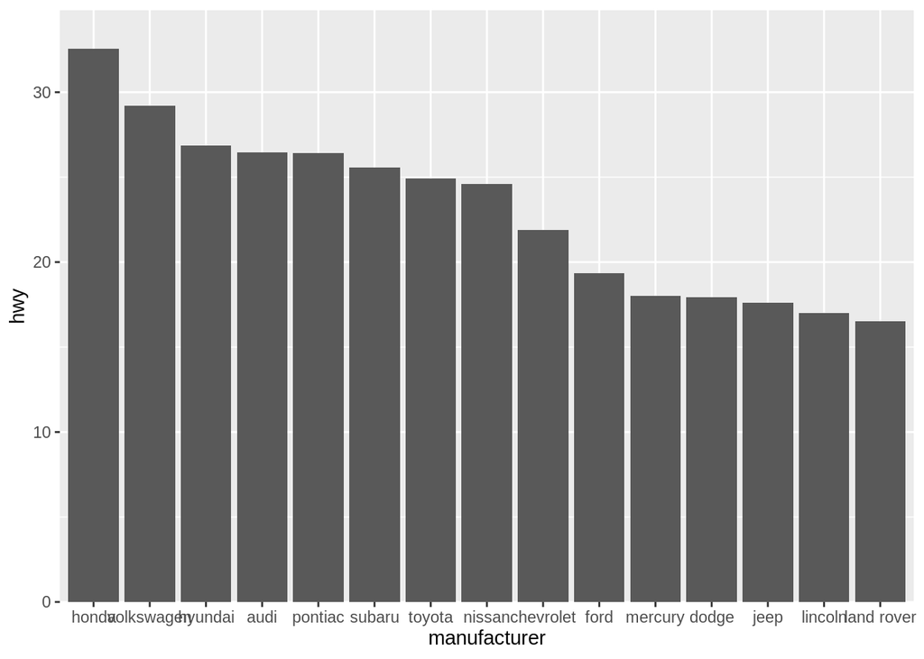

```r
library(forcats)
mpg %>%
  group_by(manufacturer) %>%
  summarise(hwy = mean(hwy)) %>%
  mutate(manufacturer = fct_reorder(manufacturer, hwy, .desc = T)) %>%
  ggplot(aes(manufacturer, hwy)) +
  geom_col() +
  scale_y_continuous(expand = expand_scale(mult = c(0, 0.07)))
```

By reordering our graphic, we’re now able to better compare more similar manufacturers. It’s now dramatically faster to understand our visualization – closer comparisons are easier to make, so placing more similar values closer together makes them dramatically easier to grasp. Look at Pontiac vs Hyundai now, for instance. Generally speaking, don’t put things in alphabetical order - use the order you place things to encode additional information.

As a quick sidenote, I personally believe that, when working with categorical values along the X axis, you should reorder your values so the highest value comes first. For some reason, I just find having the tallest bar/highest point (or whatever is being used to show value) next to the Y axis line is much cleaner looking than the alternative:

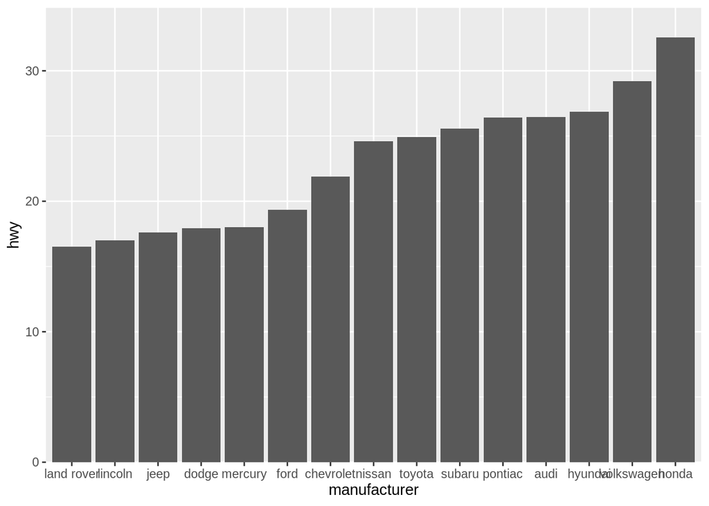

```r
mpg %>%
  group_by(manufacturer) %>%
  summarise(hwy = mean(hwy)) %>%
  mutate(manufacturer = fct_reorder(manufacturer, hwy)) %>%
  ggplot(aes(manufacturer, hwy)) +
  geom_col() +
  scale_y_continuous(expand = expand_scale(mult = c(0, 0.07)))
```

For what it’s worth, I’m somewhat less dogmatic about this when the values are on the Y axis. I personally believe the highest value should always be at the top, as humans expect higher values to be further from that bottom left corner:

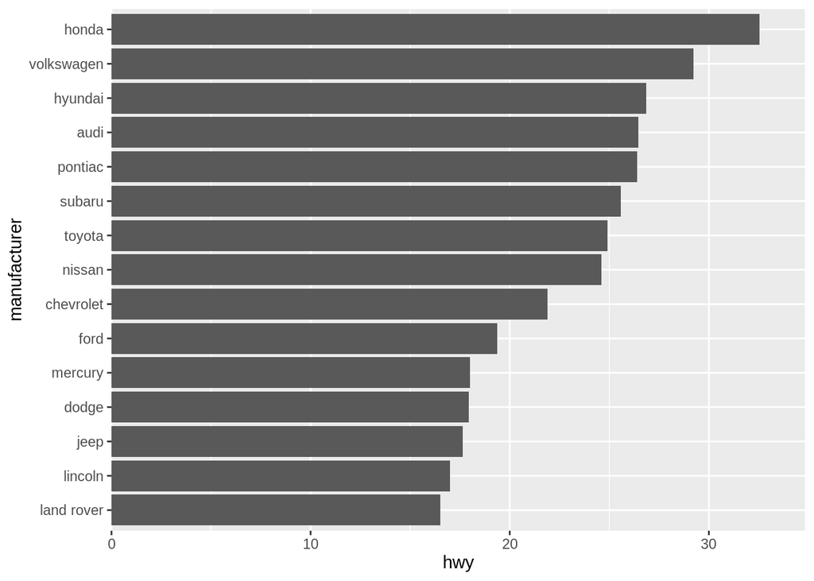

```r
mpg %>%
  group_by(manufacturer) %>%
  summarise(hwy = mean(hwy)) %>%
  mutate(manufacturer = fct_reorder(manufacturer, hwy)) %>%
  ggplot(aes(manufacturer, hwy)) +
  geom_col() +
  scale_y_continuous(expand = expand_scale(mult = c(0, 0.07))) +
  coord_flip()
```

However, I’m not as instantly repulsed by the opposite ordering as I am with the X axis, likely because the bottom bar/point being the furthest looks like a more natural shape, and is still along the X axis line:

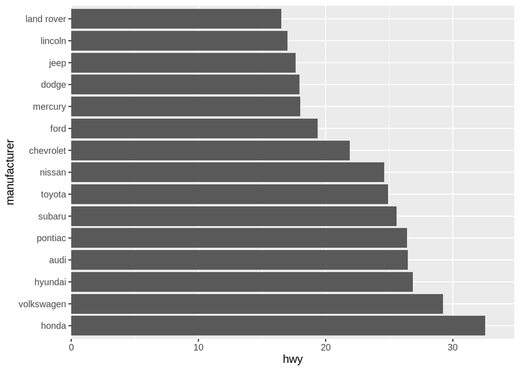

```r
mpg %>%
  group_by(manufacturer) %>%
  summarise(hwy = mean(hwy)) %>%
  mutate(manufacturer = fct_reorder(manufacturer, hwy, .desc = T)) %>%
  ggplot(aes(manufacturer, hwy)) +
  geom_col() +
  scale_y_continuous(expand = expand_scale(mult = c(0, 0.07))) +
  coord_flip()
```

For this, at least, your mileage may vary. Also, it’s worth pointing out how much cleaner the labels on this graph are when they’re on the Y axis - flipping your coordinate system, like we’ve done here, is a good way to display data when you’ve got an unwieldy number of categories.

### Color

While we’ve done a good job covering the role position plays in communicating information, we’re still stuck on the same question we started off with: How can we show a third variable on the graph?

One of the most popular ways is to use colors to represent your third variable. It might be worth talking through how color can be used with a simulated dataset. Take for example the following graph:

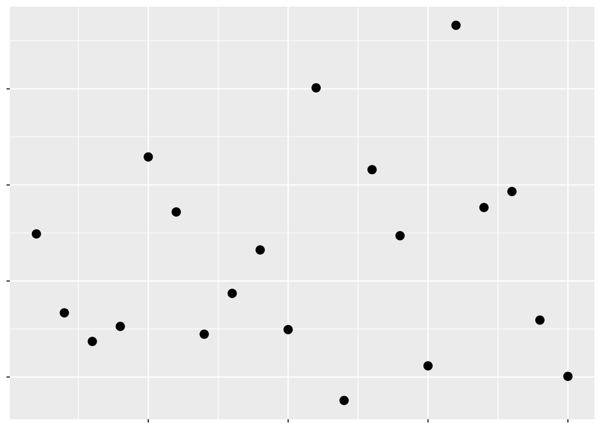

```r
df <- tibble(x = c(1:20),
        y = rnorm(20),
        z = rep(c(1, 2, 3, 4), 5))
ggplot(df, aes(x, y)) +
  geom_point(size = 3) +
  theme(text = element_blank(),
        legend.position = "null")
```

And now let’s add color for our third variable:

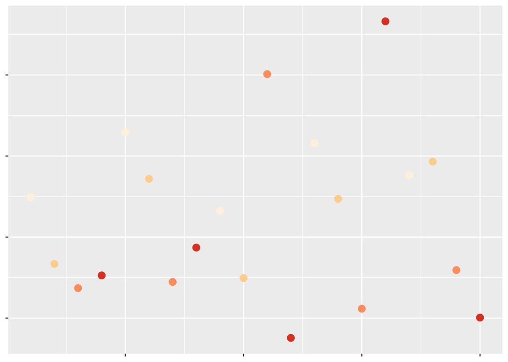

```r
ggplot(df, aes(x, y, color = factor(z))) +
  geom_point(size = 3) +
  theme(text = element_blank(),
        legend.position = "null") +
  scale_color_brewer(palette = "OrRd")
```

Remember: perceptual topology should match data topology. Which values are larger?

Most people would say the darker ones. But is it always that simple? Let’s change our color scale to compare:

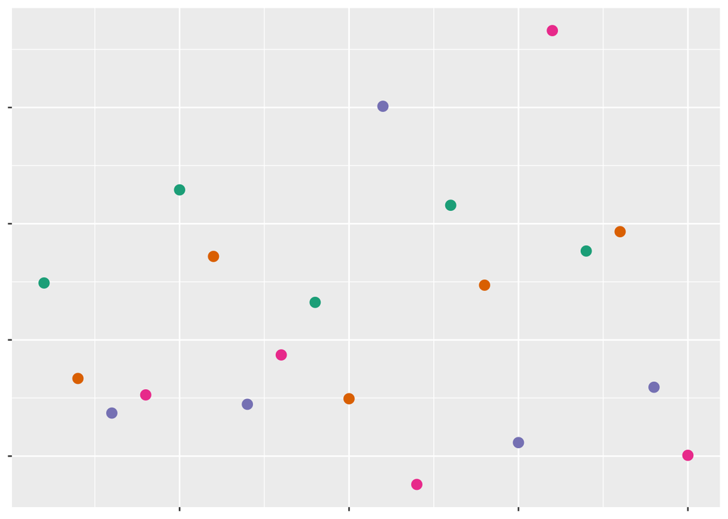

```r
ggplot(df, aes(x, y, color = factor(z))) +
  geom_point(size = 3) +
  theme(text = element_blank(),
        legend.position = "null") +
  scale_color_brewer(palette = "Dark2")
```

Sure, some of these colors are darker than others – but I wouldn’t say any of them tell me a value is particularly high or low.

That’s because humans don’t percieve *hue* as an ordered variable - the actual color a point is doesn’t tell us how large a value is. Instead, the first graph altered the *luminance* of each point - how bright or dark it was - in order to tell us what value it has.

There’s one other axis you can move colors along in order to encode value, known as *chroma*:

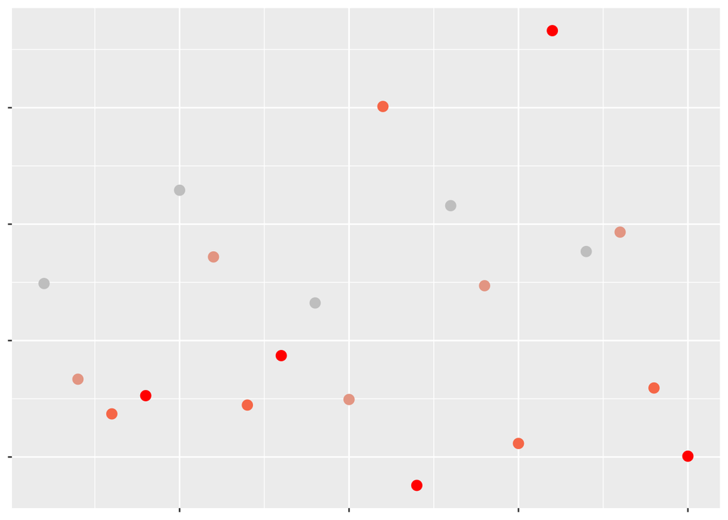

```r
ggplot(df, aes(x, y, color = z)) +
  geom_point(size = 3) +
  theme(text = element_blank(),
        legend.position = "null") +
  scale_color_gradient(low = "grey", high = "red")
```

Chroma - or how vibrant a color is - also encodes a value, with more vibrant colors representing higher values. These three values – hue, chroma, and luminence – form the HCL color spectrum, which is more or less how humans perceive colors in our daily lives. By altering the C and L components, we’re able to use color to encode numeric values in our graphics.

Now, color brings with it a number of challenges. For example, as we’ve already shown, changing the hue of a color doesn’t actually help us to encode any more information in our graphics. Combine that with the most common way to choose colors for a graphic - using the rainbow - and you wind up with a lot of graphics like this:

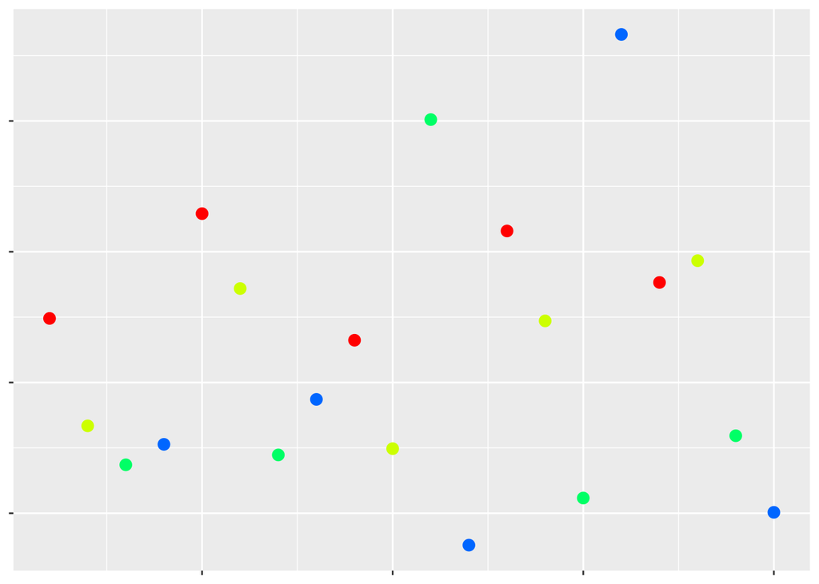

```r
ggplot(df, aes(x, y, color = factor(z))) +
  geom_point(size = 3) +
  scale_color_manual(values = rainbow(5)) +
  theme(text = element_blank(),
        legend.position = "null")
```

Which values are larger? Who knows?

Now, it’s not actually fair of me to say that hue doesn’t encode any information in our graphics. For instance, in this example, you can clearly see that blue points are different in some manner from red points. It’s more appropriate to say that hue is an *unordered value* – there’s no hue that represents a larger or smaller value than any other, but two hues do clearly represent two different values.

This becomes relevant when dealing with categorical data. For instance, moving back to the scatterplot we started with:

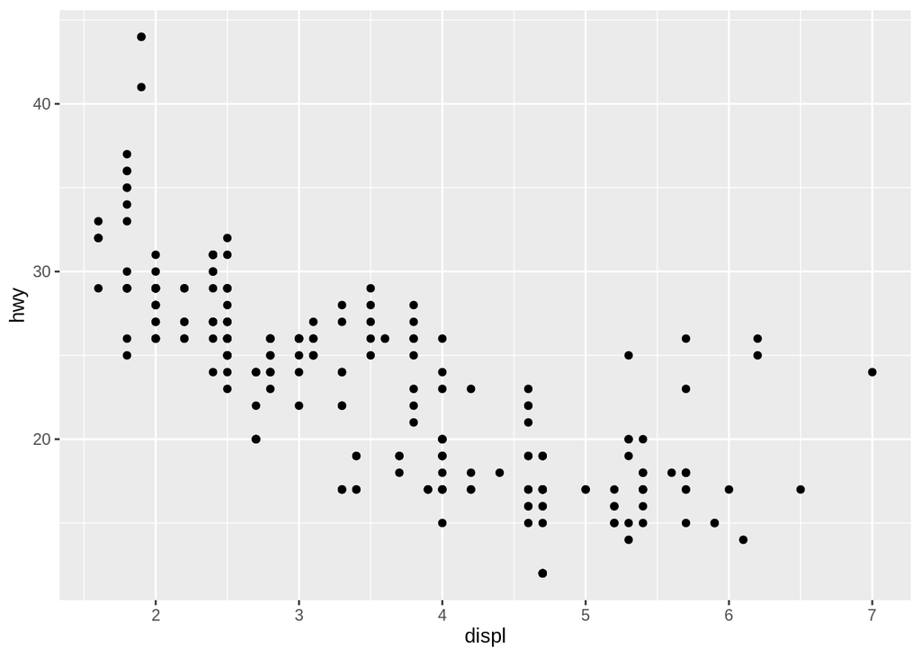

```r
ggplot(mpg, aes(displ, hwy)) +
  geom_point()
```

If we wanted to encode a categorical variable in this – for instance, the class of vehicle – we could use hue to distinguish the different types of cars from one another:

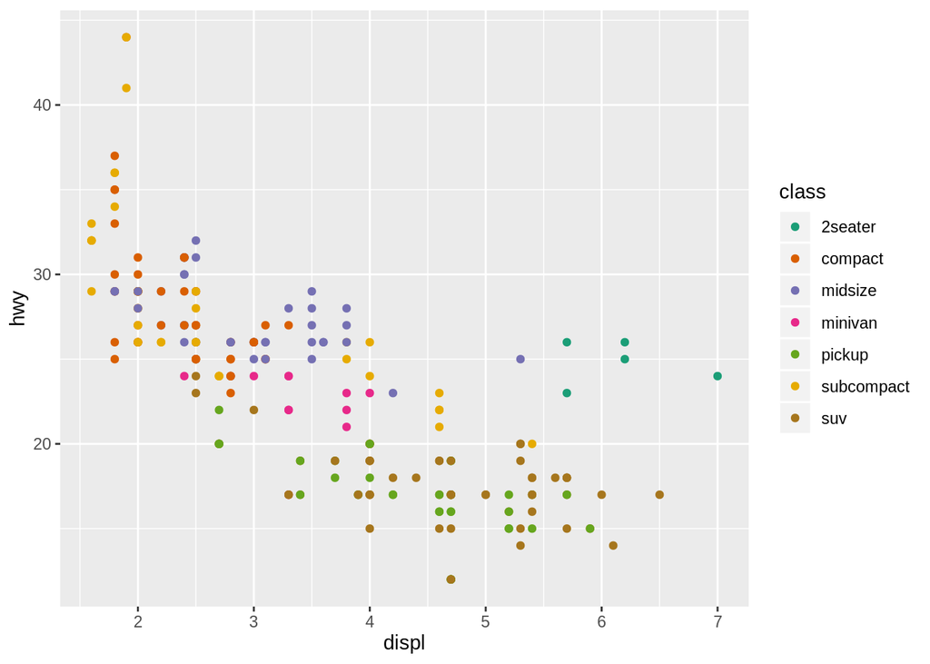

```r
ggplot(mpg, aes(displ, hwy, color = class)) +
  geom_point() +
  scale_color_brewer(palette = "Dark2")
```

In this case, using hue to distinguish our variables clearly makes more sense than using either chroma or luminesence:

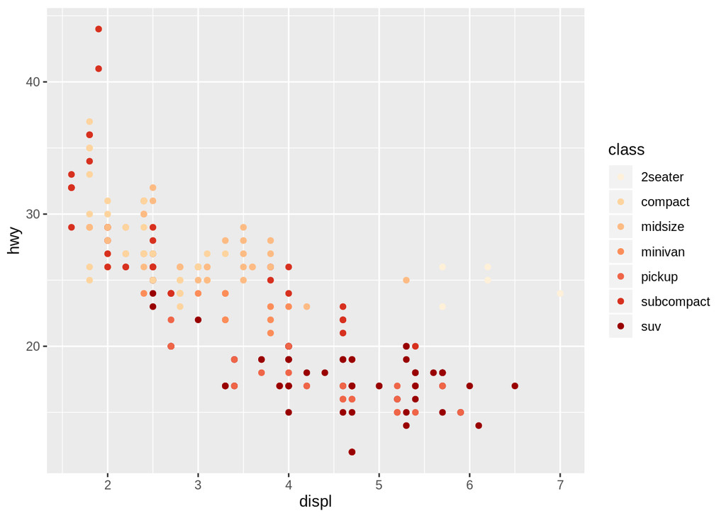

```r
ggplot(mpg, aes(displ, hwy, color = class)) +
  geom_point() +
  scale_color_brewer(palette = "OrRd")
```

This is a case of knowing what tool to use for the job - chroma and luminescence will clearly imply certain variables are closer together than is appropriate for categorical data, while hue won’t give your audience any helpful information about an ordered variable. Note, though, that I’d still discourage using the rainbow to distinguish categories in your graphics – the rainbow is not perceptually uniform (for instance, red and orange are much more similar colors than yellow and blue), and you’ll wind up implying connections between your categories that you might not want to suggest.

Speaking of knowing the right rool for the job, one of the worst things people like to do in data visualizations is overuse color. Take for instance the following example:

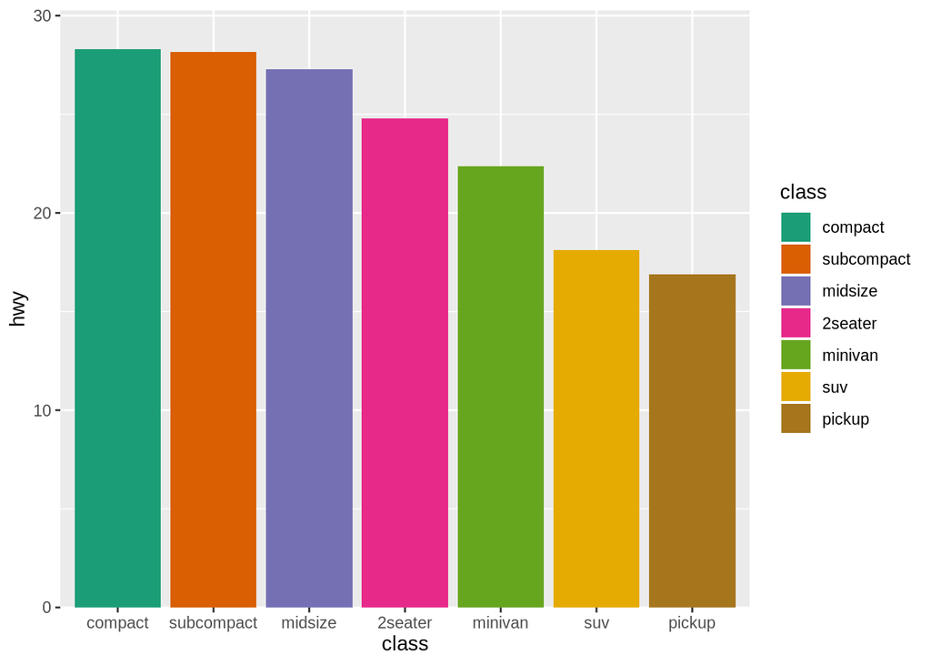

```r
mpg %>%
  group_by(class) %>%
  summarise(hwy = mean(hwy)) %>%
  mutate(class = fct_reorder(class, hwy, .desc = T)) %>%
  ggplot(aes(class, hwy, fill = class)) +
  geom_col() +
  scale_y_continuous(expand = expand_scale(mult = c(0, 0.07))) +
  scale_fill_brewer(palette = "Dark2")
```

In this graph, the variable “class” is being represented by both position, along the x axis, and by color. By duplicating this effort, we’re making our graph harder to understand – encoding the information once is enough, and doing it any more times than that is a distraction. Remember the second mantra: Everything should be made as simple as possible – but no simpler. The best data visualization is one that includes all the elements needed to deliver the message, and no more.

You can feel free to use color in your graphics, so long as it adds more information to the plot - for instance, if it’s encoding a third variable:

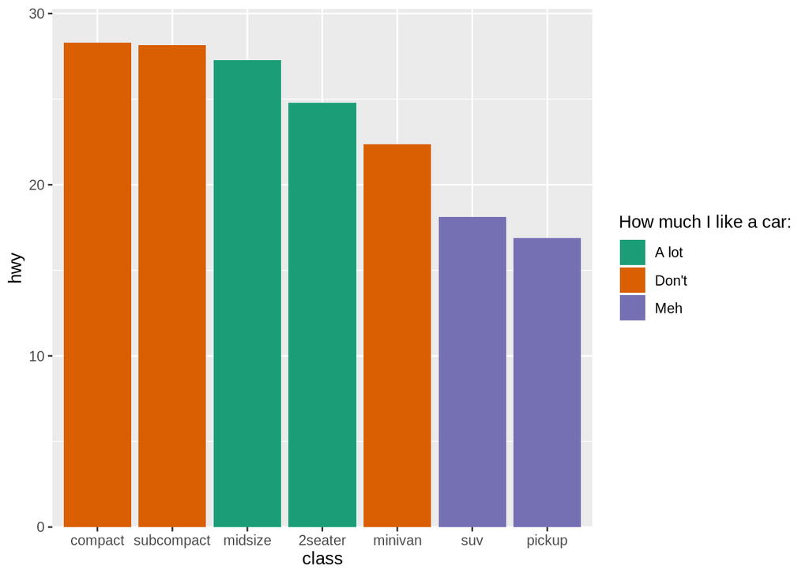

```r
mpg %>%
  group_by(class) %>%
  summarise(hwy = mean(hwy)) %>%
  mutate(class = fct_reorder(class, hwy, .desc = T),
         "How much I like a car:" = c("A lot", "Don't", "A lot", "Don't", "Meh", "Don't", "Meh")) %>%
  ggplot(aes(class, hwy, fill = `How much I like a car:`)) +
  geom_col() +
  scale_y_continuous(expand = expand_scale(mult = c(0, 0.07))) +
  scale_fill_brewer(palette = "Dark2")
```

But replicating as we did above is just adding more junk to your chart.

There’s one last way you can use color effectively in your plot, and that’s to highlight points with certain characteristics:

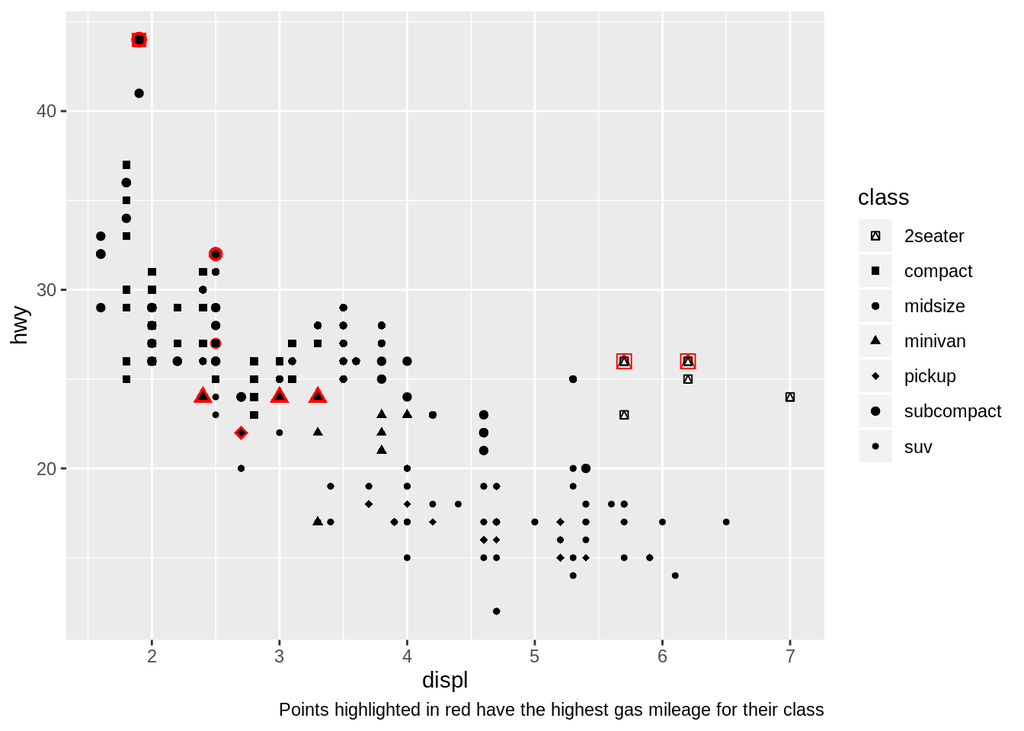

```r
mpg %>%
  group_by(class) %>%
  filter(hwy == max(hwy)) %>%
  ggplot(aes(displ, hwy)) +
  geom_point(size = 3, aes(shape = class), color = "red", show_guide = FALSE) +
  geom_point(data = mpg, aes(shape = class)) +
  labs(caption = "Points highlighted in red have the highest gas mileage for their class") +
  scale_shape_manual(values = c(14:22))
```

Doing so allows the viewer to quickly pick out the most important sections of our graph, increasing its effectiveness. Note that I used shape instead of color to separate the class of vehicles, by the way – combining point highlighting and using color to distinguish categorical variables can work, but can also get somewhat chaotic:

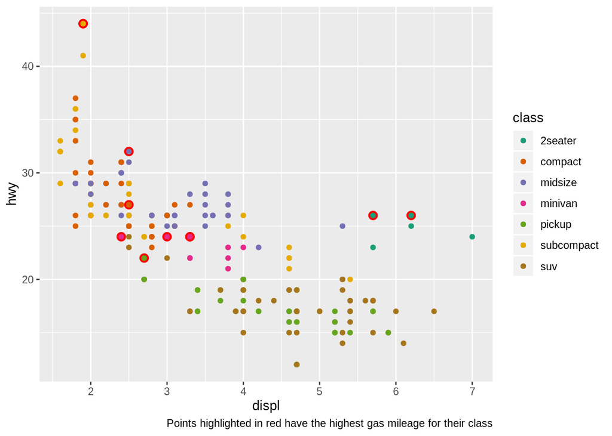

```r
mpg %>%
  group_by(class) %>%
  filter(hwy == max(hwy)) %>%
  ggplot(aes(displ, hwy)) +
  geom_point(size = 3, aes(color = class), color = "red", show_guide = FALSE) +
  geom_point(data = mpg, aes(color = class)) +
  labs(caption = "Points highlighted in red have the highest gas mileage for their class") +
  scale_shape_manual(values = c(14:22)) +
  scale_color_brewer(palette = "Dark2")
```

There’s one other reason color is a tricky aesthetic to get right in your graphics: about 5% of the population (10% of men, 1% of women) can’t see colors at all. That means you should be careful when using it in your visualizations – use colorblind-safe color palettes (google “ColorBrewer” or “viridis” for more on these), and pair it with another aesthetic whenever possible.

### Shape

The easiest aesthetic to pair color with is the next most frequently used – shape. This one is much more intuitive than color – to demonstrate, let’s go back to our scatterplot:

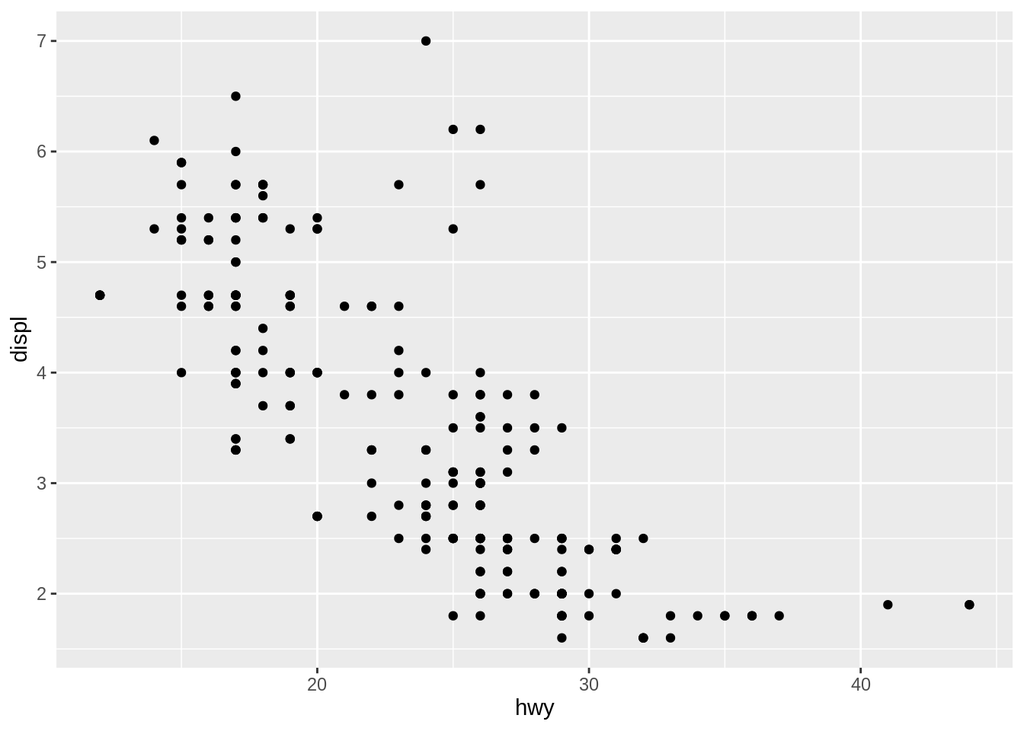

```r
ggplot(mpg, aes(hwy, displ)) +
  geom_point()
```

We can now change the shape of each point based on what class of vehicle it represents:

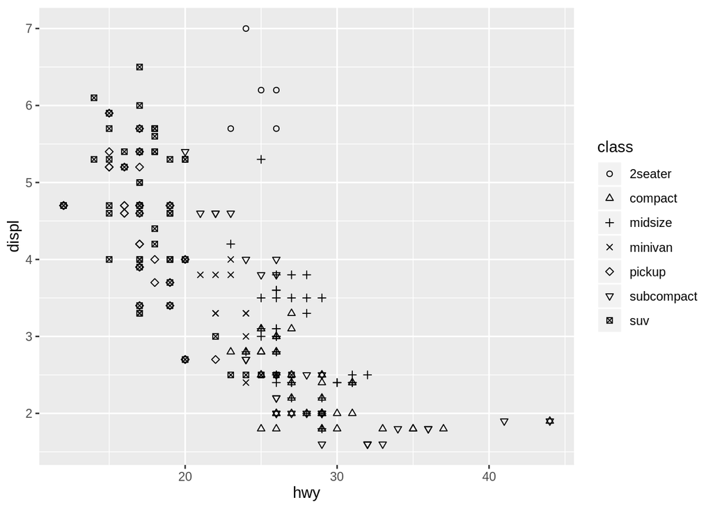

```r
ggplot(mpg, aes(hwy, displ, shape = class)) +
  geom_point() +
  scale_shape_manual(values = 1:7)
```

Imagine we were doing the same exercise as we did with color earlier – which values are larger?

I’ve spoiled the answer already by telling you what the shapes represent – none of them are inherently larger than the others. Shape, like hue, is an *unordered value*.

The same basic concepts apply when we change the shape of lines, not just points. For instance, if we plot separate trendlines for front-wheel, rear-wheel, and four-wheel drive cars, we can use linetype to represent each type of vehicle:

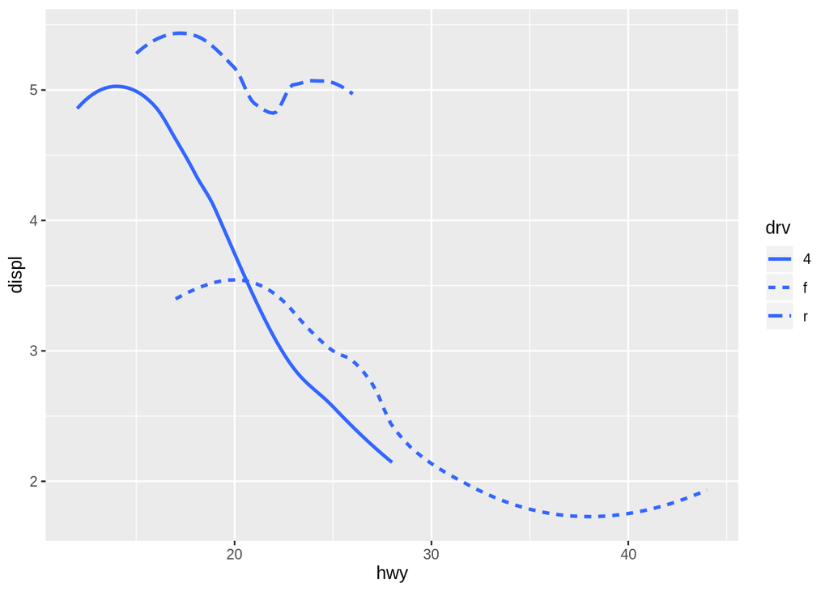

```r
ggplot(mpg, aes(hwy, displ, linetype = drv)) +
  geom_smooth(se = F)
```

But even here, no one linetype implies a higher or lower value than the others.

There are two caveats to be made to this rule, however. For instance, if we go back to our original scatterplot and change which shapes we’re using:

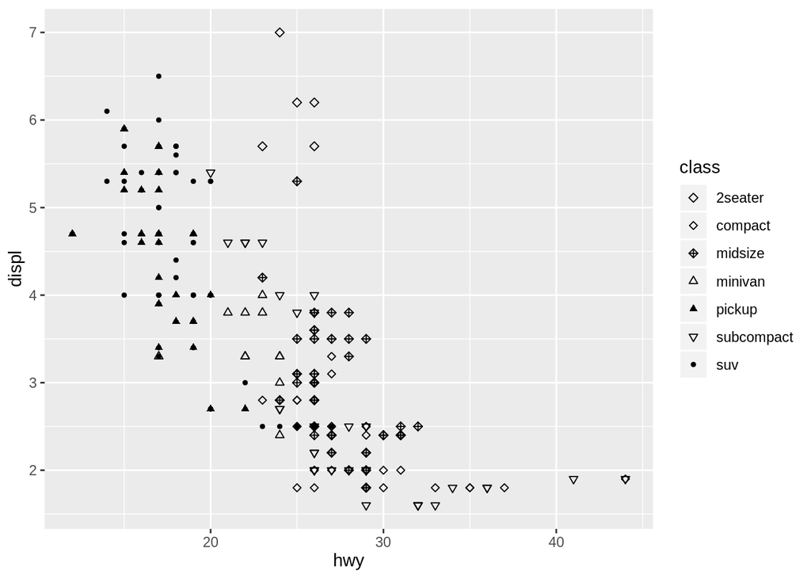

```r
ggplot(mpg, aes(hwy, displ, shape = class)) +
  geom_point() +
  scale_shape_manual(values = c(5, 23, 9, 2, 17, 6, 20))
```

This graph seems to imply more connection between the first three classes of car (which are all different types of diamonds) and the next three classes (which are all types of triangle), while singling out SUVs. In this way, we’re able to use shape to imply connection between our groupings - more similar shapes, which differ only in angle or texture, imply a closer relationship to one another than to other types of shape. This can be a blessing as well as a curse - if you pick, for example, a square and a diamond to represent two unrelated groupings, your audience might accidentally read more into the relationship than you had meant to imply.

It’s also worth noting that different shapes can pretty quickly clutter up a graph. As a general rule of thumb, using more than 3-4 shapes on a graph is a bad idea, and more than 6 means you need to do some thinking about what you actually want people to take away.

### Size

Our last aesthetic is that of size. Going back to our original scatterplot, we could imagine using size like this:

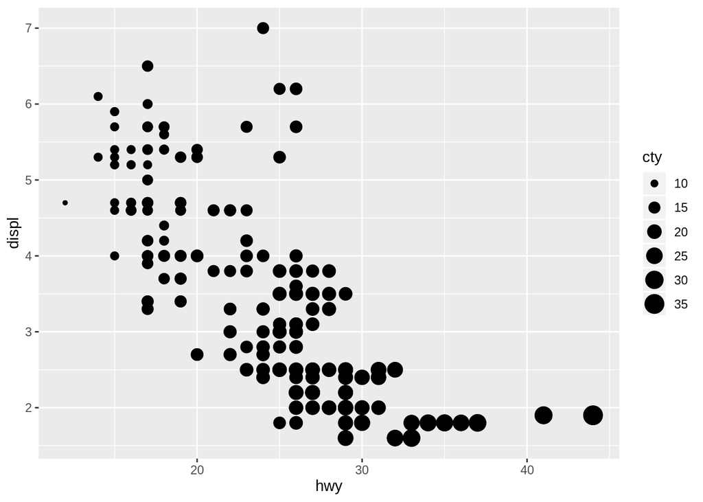

```r
ggplot(mpg, aes(hwy, displ, size = cty)) +
  geom_point()
```

Size is an inherently *ordered value* - large size points imply larger values. Specifically, humans perceive larger areas as corresponding to larger values - the points which are three times larger in the above graph are about three times larger in value, as well.

This becomes tricky when size is used incorrectly, either by mistake or to distort the data. Sometimes an analyst maps radius to the variable, rather than area of the point, resulting in graphs as the below:

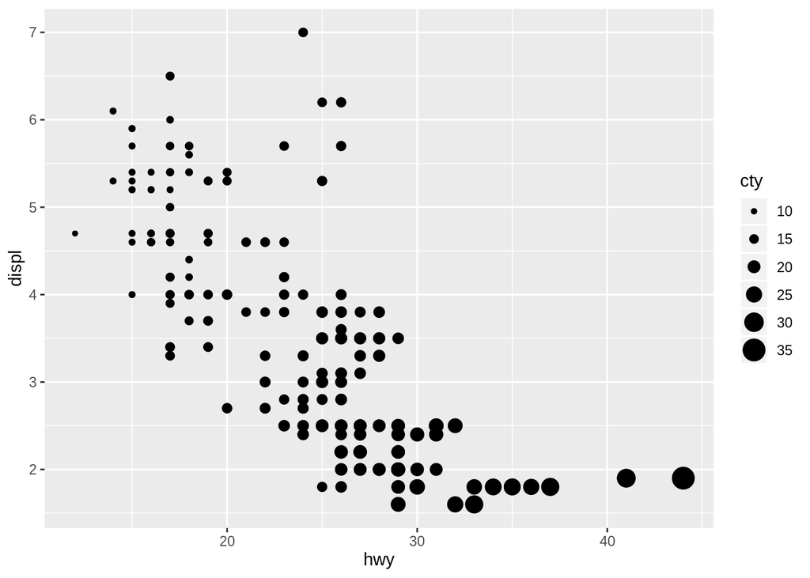

```r
ggplot(mpg, aes(hwy, displ, size = cty)) +
  geom_point() +
  scale_radius()
```

In this example, the points representing a cty value of 10 don’t look anything close to 1/3 as large as the points representing 30. This makes the increase seem much steeper upon looking at this chart – so be careful when working with size as an aesthetic that your software is using the area of points, not radius!

It’s also worth noting that unlike color – which can be used to distinguish groupings, as well as represent an ordered value – it’s generally a bad idea to use size for a categorical variable. For instance, if we mapped point size to class of vehicle:

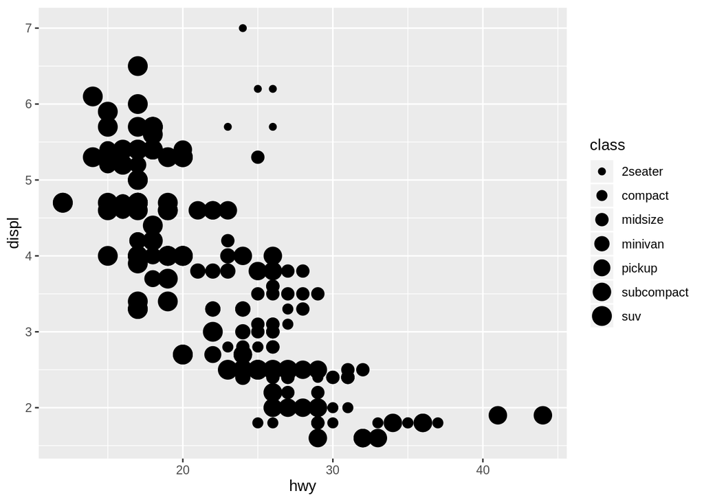

```r
ggplot(mpg, aes(hwy, displ, size = class)) +
  geom_point()
```

We seem to be implying relationships here that don’t actually exist, like a minivan and midsize vehicle being basically the same. As a result, it’s best to only use size for continuous (or numeric) data.

### A Tangent

Now that we’ve gone over these four aesthetics, I want to go on a quick tangent. When it comes to how quickly and easily humans perceive each of these aesthetics, research has settled on the following order:

1. Position
2. Size
3. Color (especially chroma and luminescence)
4. Shape

And as we’ve discussed repeatedly, the best data visualization is one that includes exactly as many elements as it takes to deliver a message, and no more. Everything should be made as simple as possible, but no simpler.

However, we live in a world of humans, where the scientifically most effective method is not always the most popular one. And since color is inherently more exciting than size as an aesthetic, the practitioner often finds themselves using colors to denote values where size would have sufficed. And since we know that color should usually be used alongside shape in order to be more inclusive in our visualizations, size often winds up being the last aesthetic used in a chart. This is fine - sometimes we have to optimize for other things than “how quickly can someone understand my chart”, such as “how attractive does my chart look” or “what does my boss want from me”. But it’s worth noting, in case you see contradictory advice in the future - the disagreement comes from if your source is teaching the most scientifically sound theory, or the most applicable practice.

### Summary

We started off this section with our second mantra: that everything should be made as simple as possible, but no simpler. The first half of that cautions us against overusing aesthetics and against adding too much to a graphic, lest we erode its efficency in conveying information:

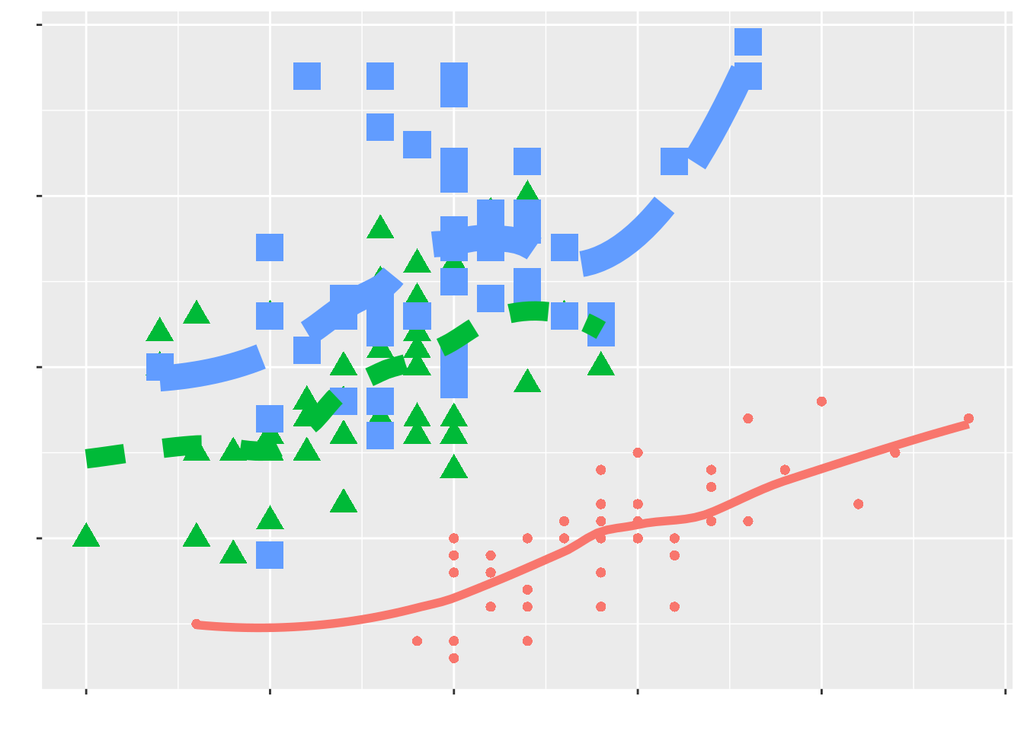

```r
ggplot(iris, aes(Sepal.Width, Sepal.Length, color = Species, size = Species, shape = Species)) +
  geom_point() +
  geom_smooth(se = F, aes(linetype = Species)) +
  theme(legend.position = "none",
        axis.text = element_blank()) +
  labs( x = "",
        y = "")
```

The second half cautions us against not using all the aesthetics it takes to tell our story, in case we don’t produce the most expressive graphic possible:

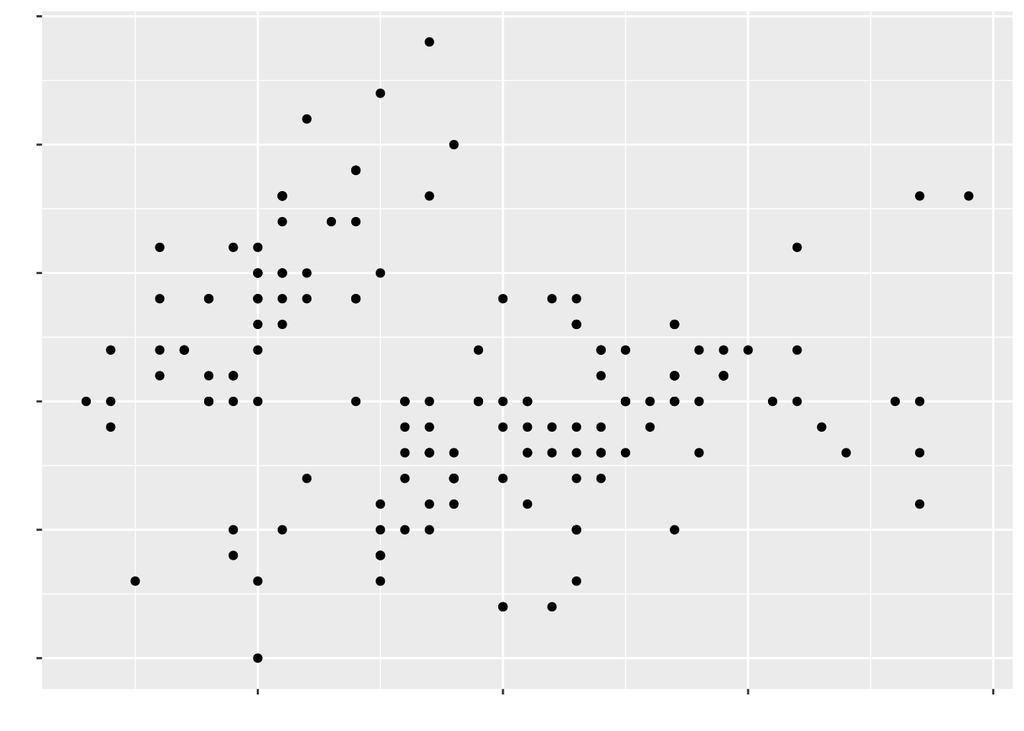

```r
ggplot(iris, aes(Sepal.Length, Sepal.Width)) +
  geom_point() +
  theme(legend.position = "none",
        axis.text = element_blank()) +
  labs( x = "",
        y = "")
```

Instead, we should use exactly as many aesthetics as it takes to tell our story, carefully choosing each to encode the most information possible into our graphics:

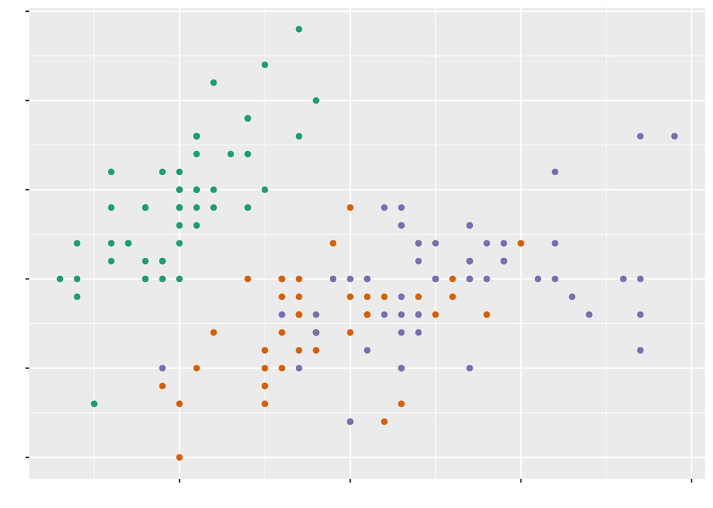

```r
ggplot(iris, aes(Sepal.Length, Sepal.Width, color = Species)) +
  geom_point() +
  scale_color_brewer(palette = "Dark2") +
  theme(legend.position = "none",
        axis.text = element_blank()) +
  labs( x = "",
        y = "")
```

As for the specific takeaways from this section, I can think of the following:

- Match perceptual and data topology – if a color or position *feels like a higher value*, use it to represent data that is a higher value
- Make important comparisons easy – place them near each other, call attention to them
- Use aesthetics to encode more information into your graphics
  - Use exactly as many aesthetics as you need – no more, no less.
- Don’t place things in alphabetical order
- Don’t use the rainbow for a color scheme
- Use ordered aesthetics (like position, chroma, luminescence, and size) to show ordered values (like numeric data)
- Use unordered aesthetics (like hue or shape) to show unordered values